# R Code used in Review Lecture

Edward Vytlacil

June 20, 2023

This file contains the code corresponding to the review lecture. The review lecture can be downloaded [here](https://edward-vytlacil.github.io/GEC/Review_Lecture.pdf)

## Slides 8 and 10

- Using R as calculator to compute expected returns, variance of returns of hypothetical investments in slides 8 and 10

```r
#Expected return of investment in risk-free treasury bills.  .
e_r_f <- 1 * 1500/1000000
print(e_r_f)
```

```
## [1] 0.0015
```

```r
#Expected and variance of return of investment in risky startup
e_r <- .5 * (-1) + .5 * 1005000/1000000
print(e_r)
```

```
## [1] 0.0025
```

```r
v_r <- .5 *(-1-e_r)^2 + .5 * (1005000/1000000-e_r)^2
print(v_r)
```

```
## [1] 1.005006
```

## Slides 13-14

- Hypothetical example of risk-return tradeoff for investing in Ford vs Tesla.
- creating the figures for slides 13-14
- using ggplot2 to create the figure, you need to install the package first if you have not done so already.

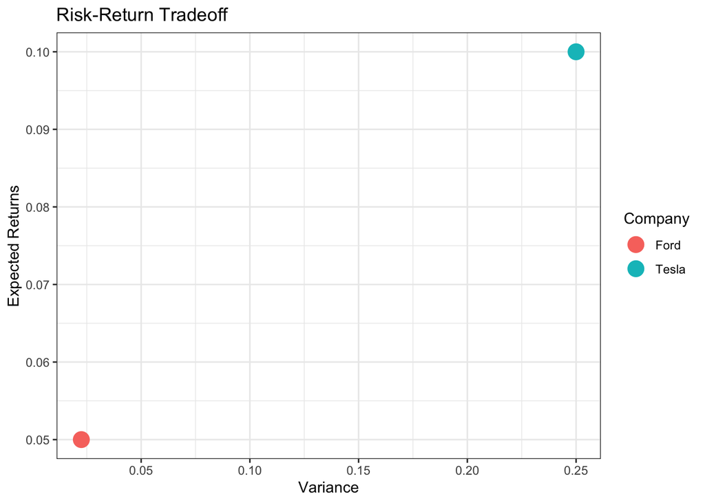

```r
library(ggplot2)

Company <- c("Tesla", "Ford")
Er      <- c(0.1,0.05)
Var     <- c(0.25,0.0225)

df <- data.frame(Company,Er,Var)

ggplot(df, aes(x = Var, y = Er, color = Company)) +
    geom_point(size = 5) +
    theme_bw() + ggtitle("Risk-Return Tradeoff") +
    xlab("Variance") + ylab("Expected Returns")
```

## Slides 17-18

- Example of Morgan Stanley and Genworth Financial returns
- $r_B$ are Morgan Stanley monthly returns
- $r_C$ are returns Genworth Financial monthly returns.
- use readstata13 package to read in data set in STATA format. You need to install package first if you have not done so already.

```r
library(readstata13)  #need this library for read.dta13 function, data set is in STATA format.
data <- read.dta13("https://edward-vytlacil.github.io/Data/financeR.dta")

cov(data$r_B,data$r_C)
```

```
## [1] 0.01325161
```

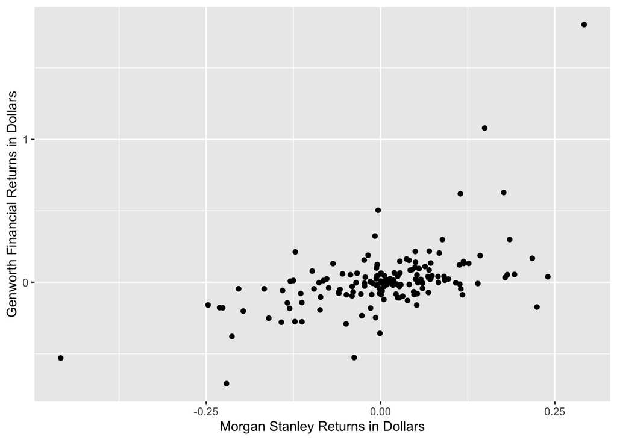

```r
ggplot(data,aes(x=data$r_B,y=data$r_C))+
  geom_point()+
  xlab("Morgan Stanley Returns in Dollars")+
  ylab("Genworth Financial Returns in Dollars")
```

```r
cor(data$r_B,data$r_C)
```

```
## [1] 0.5437336
```

- Risk-Return tradeoff (expected return/variance of return tradeoff) for portfolio with:
- wF fraction of investment in Ford
- wT fraction of investment in Tesla
- Scenario with **positive covariance** in returns

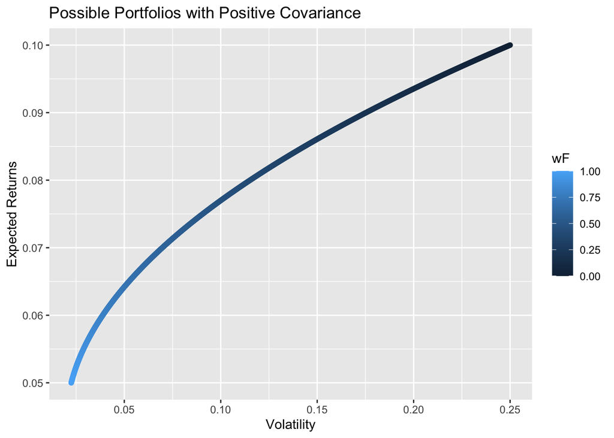

```r
# library(ggplot2)
er_F   <- 0.05   # Expected Returns
er_T   <- 0.1
var_F  <- 0.0225 # Variances/Risk
var_T  <- 0.25
cov_FT <- 0.045  # Covariance

weights <- seq(from = 0, to = 1, length.out = 1000)
tab <- data.frame(wF = weights, wT = 1 - weights)
tab$er_p  <-  tab$wF * er_F + tab$wT * er_T
tab$var_p <-  tab$wF^2*var_F +tab$wT^2*var_T +2* tab$wF *(1 - tab$wF)*cov_FT

ggplot() + geom_point(data = tab,
                      aes(x = var_p, y = er_p, color = wF)) +
    ggtitle("Possible Portfolios with Positive Covariance") +
    xlab("Volatility") +
    ylab("Expected Returns")
```

## Slides 32-33

- Risk-Return tradeoff (expected return/variance of return tradeoff) for portfolio with:
- wF fraction of investment in Ford
- wT fraction of investment in Tesla
- Scenario with **negative covariance** in returns

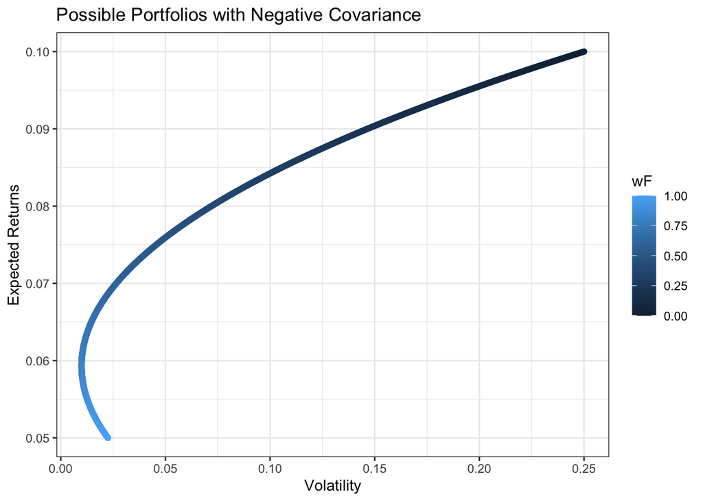

```r
#library(ggplot2)
er_F   <- 0.05   # Expected Returns
er_T   <- 0.1
var_F  <- 0.0225 # Variances/Risk
var_T  <- 0.25
cov_FT <- - 0.045  # Covariance

weights <- seq(from = 0, to = 1, length.out = 1000)
tab <- data.frame(wF = weights, wT = 1 - weights)
tab$er_p  <-  tab$wF * er_F + tab$wT * er_T
tab$var_p <-  tab$wF^2*var_F +tab$wT^2*var_T +2* tab$wF *(1 - tab$wF)*cov_FT

ggplot() + geom_point(data = tab,
                      aes(x = var_p, y = er_p, color = wF)) +
    theme_bw() +
    ggtitle("Possible Portfolios with Negative Covariance") +
    xlab("Volatility") +
    ylab("Expected Returns")
```